# Solving Problems by Searching

Ayeshma Nanayakkara

# Informed (Heuristic) Search Strategies

- Use problem‐specific knowledge
- Applications:
  - Navigation and Path finding : GPS Navigation
  - Natural Language Processing: Machine Translation
  - Game Playing: Chess, tic-tac-toe
  - Robotics and Autonomous Systems
- Efficient than uninformed search strategies
- General approach:
  - best‐*first* search [node is selected for expansion based on an evaluation function *f(n)*]
  - *f(n)* measures distance to goal from node n
- Expand node with lowest f‐value
- An instance of TREE‐SEARCH algorithm with a priority queue (ordered by f ) for the frontier
- Key component of f: a heuristic function h(n), estimated cost of cheapest path from node n to a goal node

## Greedy Best-First Search

Nodes are expanded based on:
$$f(n) = h(n)$$

Example: Route finding problem (Agent in city A, wishes to go to city M)

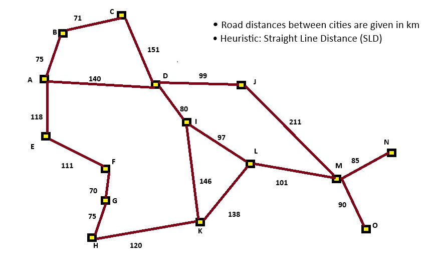

• Straight‐line distances (SLD), in km, from city M are given below

| City | SLD |  | City | SLD |  | City | SLD |
| --- | --- | --- | --- | --- | --- | --- | --- |
| A | 366 |  | F | 244 |  | K | 160 |
| B | 374 |  | G | 241 |  | L | 100 |
| C | 380 |  | H | 242 |  | M | 0 |
| D | 253 |  | I | 193 |  | N | 80 |
| E | 329 |  | J | 176 |  | O | 77 |

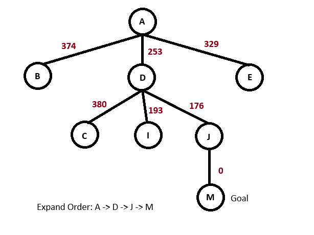

## A* Search

- Most widely‐known form of best‐first search
- Google Maps uses A* algorithm
- Evaluates nodes using:
  $$f(n) = g(n) + h(n)$$
- g(n): cost to reach node n from initial state
- h(n): estimated cost of cheapest path to goal from node n
- f(n): estimated cost of cheapest solution through node n

Example: 8-Puzzle Game

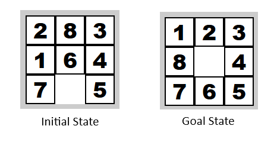

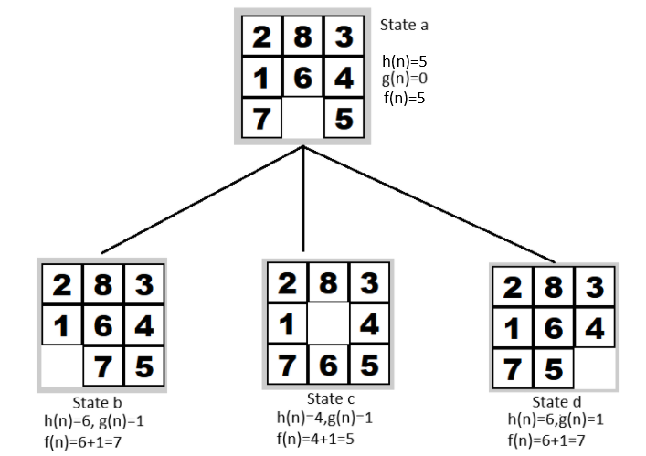

## Local Search Algorithms

- Operate using a single current state and move only to neighbors of that state
- Paths followed by search are not retained (only one path in memory)
- Pros: Less memory usage
- Cons: Fast but incomplete due to stop in local maxima

### Hill Climbing [steepest‐ascent version]

- Moves in the direction of uphill
- Terminates when reaches a “peak” where no neighbor is better

**function** HILL‐CLIMBING(*problem*) **returns** a state that has a maximum  
*current*<-MAKE‐NODE(*problem*.INITIAL‐STATE)  
**loop do**  
*neighbor*<-a lowest heuristic valued successor of *current*  
**if**  
*neighbor*.HEURISTIC>=*current*.HEURISTIC **then return** *current*.STATE *current*<-neighbor

**Example (8-Queens Problem):**

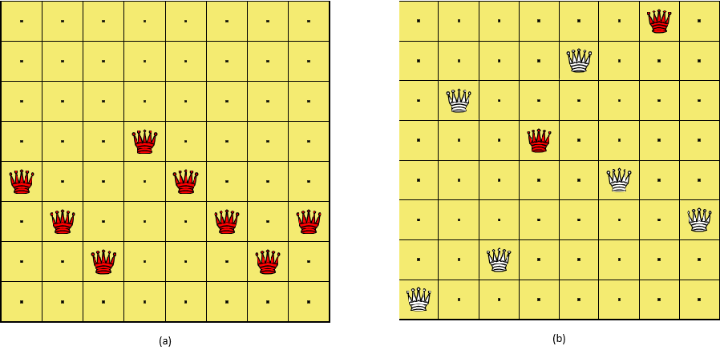

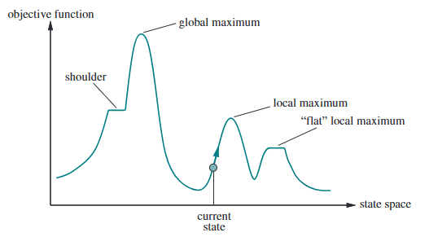

- Local Maximum: A state better than it’s neighbors but not the best
- Global Maximum: State highest value of objective function
- Current state: Present state of an agent
- Flat local maximum: Flat space where all neighbors have the same value.
- Shoulder: Plateau region which has an up hill edge.It can be a flat local Plateau maximum, from which no uphill exit exists

## References

- Artificial Intelligence: A Modern Approach, Russell, S. and Norvig, P., Pearson, Fourth Edition, 2022
- Artificial Intelligence: Structures and Strategies for Complex Problems Solving, Lurger GF, Addison Wesley, Sixth Edition, 2008

**Thank You!**